# Getting Functionnal-structural plant model into a pipeline:

MARSHAL pipeline

Adrien Heymans, Felicien Meunier et Guillaume Lobet

November 2018

# Introduction

The coupling of models with one another can be use to find releavant sequence of information. Depending of the models, the complexity of the system is significantly increase. Here, the system on which this pipeline works is a below ground system. It focuses on solving the hydraulic architecture of a root system. To illustrate the necessity of merging models together, we start by the fact that MARSHAL need an explicit root system architecture to add on the hydraulic part. **CRootBox** is precisely a model that compute the explicit root system architecture and **MARSHAL** was designed to accept easily the CRootBox output. Dealing with models as an input for another model will also increase the dynamic approach of the overall.

## How to use MARSHAL in a R environment

To run this example, the marshal package is required. This package can be found on GitHub:

- https://github.com/MARSHAL-ROOT/marshal

or by simply excecute the following line:

```r
install.packages("devtools")
library(devtools)
install_github("MARSHAL-ROOT/marshal")
library(marshal)
```

MARSHAL is built upon a handfull of other packages that need to be loaded. One groupe of function has to be loaded manually and is stored :

- https://github.com/MARSHAL-ROOT/marshal-pipeline/R/

```r
library(data.table)
library(tidyverse)
library(Matrix)
library(readxl)
library(cowplot)
library(xml2)
library(knitr)
#library(marshal) # ! not working
`%!in%` <- compose(`!`, `%in%`)

source("R/io_function.R")
# Working version of MARSHAL
source("R/getSUF.R")
```

Once it is installed, the boundary condition on which the model works should be implemeted.

# Boundary condition of MARSHAL.

The bondary condition to MARSHAL are :

- The hydraulic properties of the root system
- The water potential of the soil
- The root system architecture
- The initial pressure strength that pull water out of the collar

## Hydraulic properties of the root system

#### The axial conductance

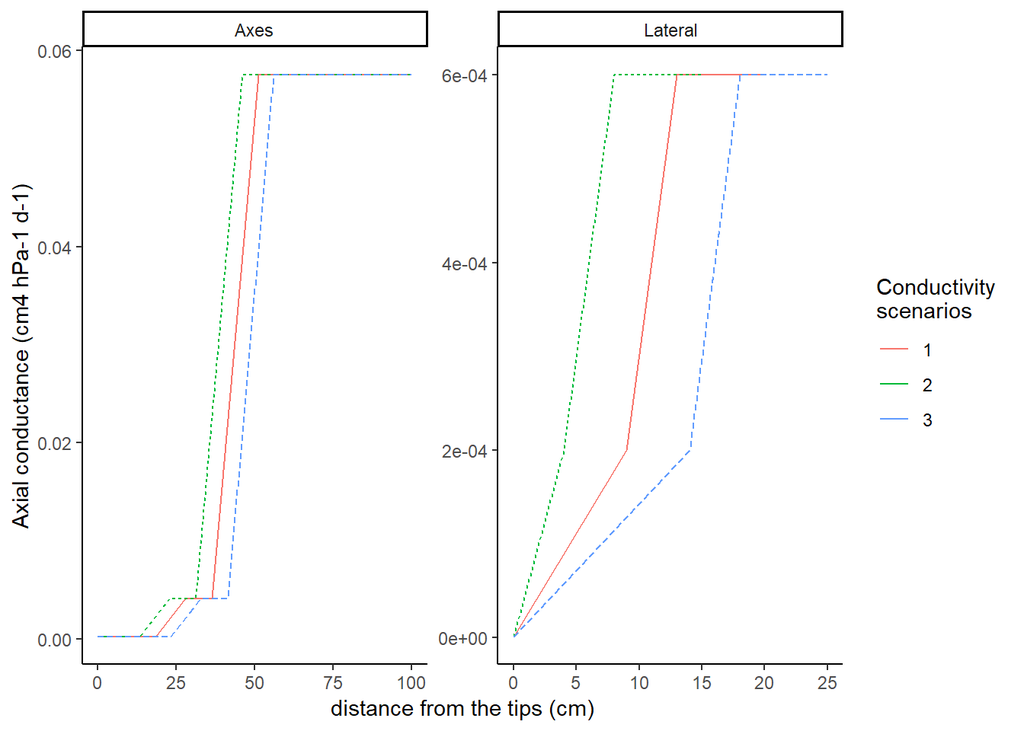

Axial conductance on axes and lateral root type

#### The radial conductivity

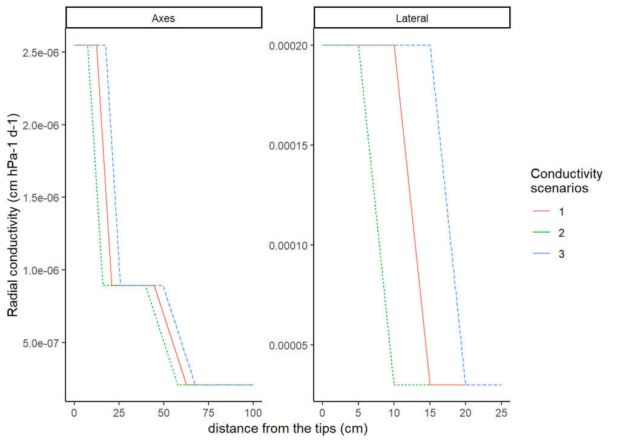

## Root system architecture with CRootBox

Modelling root system architecture can be achieve with CRootBox for instance. Some examples of the parametre files for a couples of specieses are details in the *modelparameter* folder, which is linked to the CRootBox depository.

- https://github.com/Plant-Root-Soil-Interactions-Modelling/CRootBox

For the purpose of the example we choose to work with three parameter file of Maize:

- “Zea_mays_3_Postma_2011”
- “Zea_mays_1_Leitner_2010”
- “Zea_mays_4_Leitner_2014”

```r
# Number of repetion per root system architecture example
nrep <- 5

# List of three CrootBox parameter for corn
param_choise <- c("Zea_mays_1_Leitner_2010",
                  "Zea_mays_3_Postma_2011",
                  "Zea_mays_4_Leitner_2014")

all_roots <- NULL
for(param_name in param_choise){
  # Load param of the selected example
  rparam <- read_rparam(path = paste0("./www/", param_name, ".rparam"))
  pparam <- read_pparam(path = paste0("./www/", param_name, ".pparam"))
  # Overwrite the param files that will be use
  write_rparam(rparam, "./www/param.rparam")
  write_pparam(pparam, "./www/param.pparam")

  for(i in c(1:nrep)){
  # Run CRootBox ----
  system("www/a.exe")

  # Get all the files exported by CRootBox
  fls <- list.files("./")
  fls <- fls[grepl("rootsystem.txt", fls)]

  for(f in fls){
    temp <- fread(f, header = T)
    temp$age <- strsplit(f, "_")[[1]][1]
    temp$rep <- i
    temp$ex <- param_name
    all_roots <- rbind(all_roots, temp)
  }
  }
}

# Saving the root system information
# write_csv(all_roots, "all_roots.csv")
# all_roots <- read.csv("all_roots.csv")

# Take the same time variable as the one that were implemented in CRootBox.
full_time <- sort(unique(as.numeric(all_roots$age)))
time_step = full_time[2]-full_time[1]
endTime = max(full_time)
ntimesteps = endTime/time_step
```

#### The root system architecture

The following figure shows the root system architectures that come out CRootBox at the half of the simulation time.

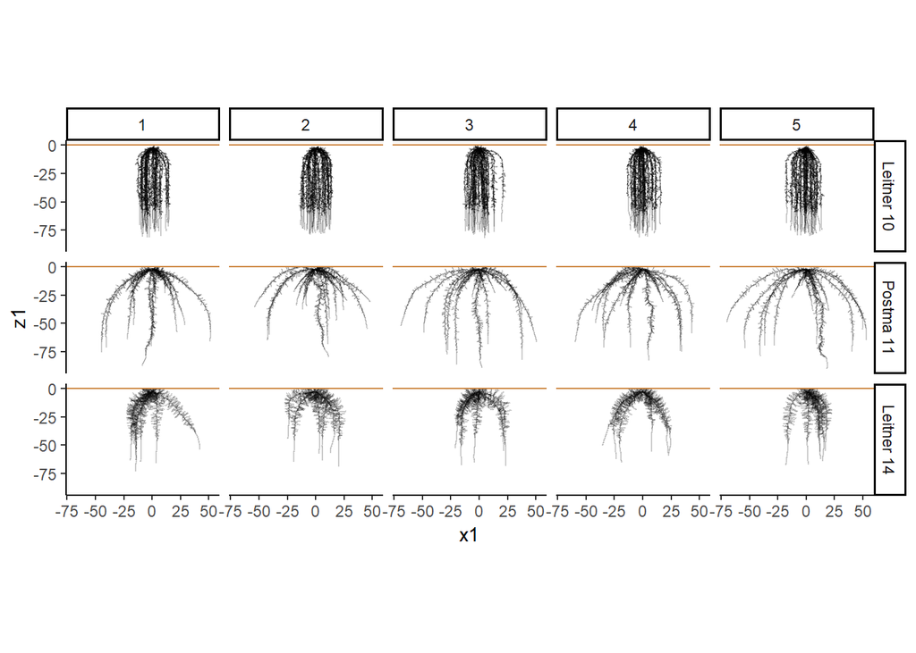

Projection in two dimentions of the different root systems computed with CRootBox at the age of 30 days

### Architectural phenes

Once the complete root system architecture is computed there are a number of architetural phenes that we can access.

#### The convex hull

The convex hull is one of the most commun known traits to works with. It gives a qualitative information about root exploration. To find the convex hull with an explicit root system in 3D is straight forwards. Thanks to the chull function, we are able to identify all the coordinates that make the convex hull and the Polygon function in the sp package allows us to determine the area of the convex hull.

```r
root_20 <- all_roots%>%
  filter(age %in% c("20","40","60"))
pol_ch = poly_area<- NULL
for(i in unique(all_roots$ex)){
  for(j in unique(all_roots$rep)){
    for(ag in unique(root_20$age)){
      for(xy in c("x", "y")){# get the convex hull from two sides
    tmp <- root_20%>%
      filter(ex == i, rep == j, age == ag)%>%
      select(paste0(xy,"2"),z2, ex, rep, age)
      # select(x2,z2, ex, rep, age)
    first_col <- tmp[,1]
    x <- matrix(c(first_col, tmp$z2), nc = 2)
    ch <- chull(x= first_col, y = tmp$z2)
    ch <- c(ch, ch[1])

    # Area of the convex hull
    xy.coords <- cbind(first_col, tmp$z2)
    chull.coords <- xy.coords[ch,]
    chull.poly <- sp::Polygon(chull.coords, hole = F)
    chull.area <- chull.poly@area

    polyg <- cbind(as.data.frame(x[ch,]), ex = i, rep = paste0(j,xy), age = ag)
    pol_area <- c(chull.area/10000)%>% # Transformation into square meter
                    as.tibble()%>%
                    transmute(area = value, ex = i, rep= paste0(j,xy), age = as.numeric(ag))
    poly_area <- rbind(poly_area, pol_area)
    pol_ch <- rbind(pol_ch, polyg)
      }
    }
  }
}
```

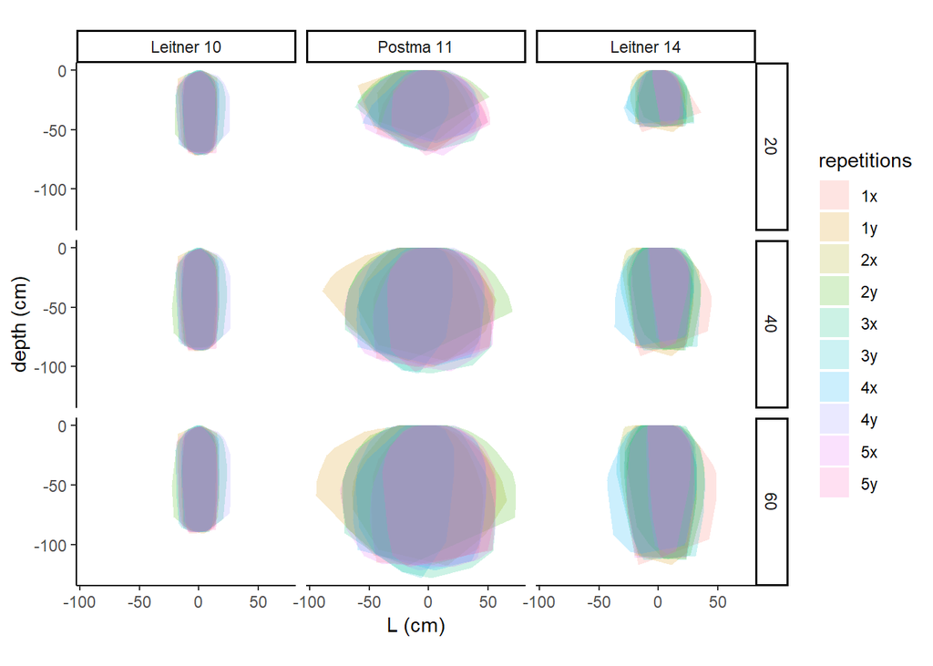

Convex hull of the root system examples x and y axes together

#### The area of the convex hull.

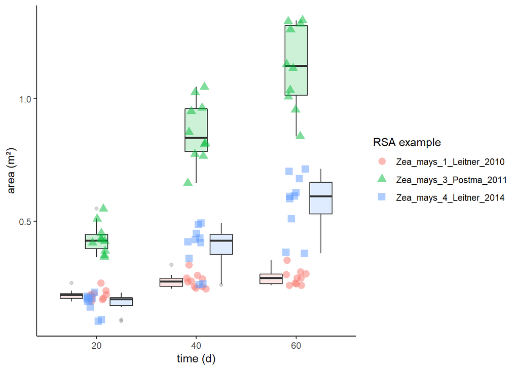

Area of the convex hull of the different root system examples

#### The maximal rooting depth

```r
# Summarise the total root length and the rooting depth information.
RLD <- all_roots%>%
  mutate(age = as.numeric(age))%>%
  group_by(age, rep, ex)%>%
  summarise(root = sum(length),
            rooting_depth = min(z2))
```

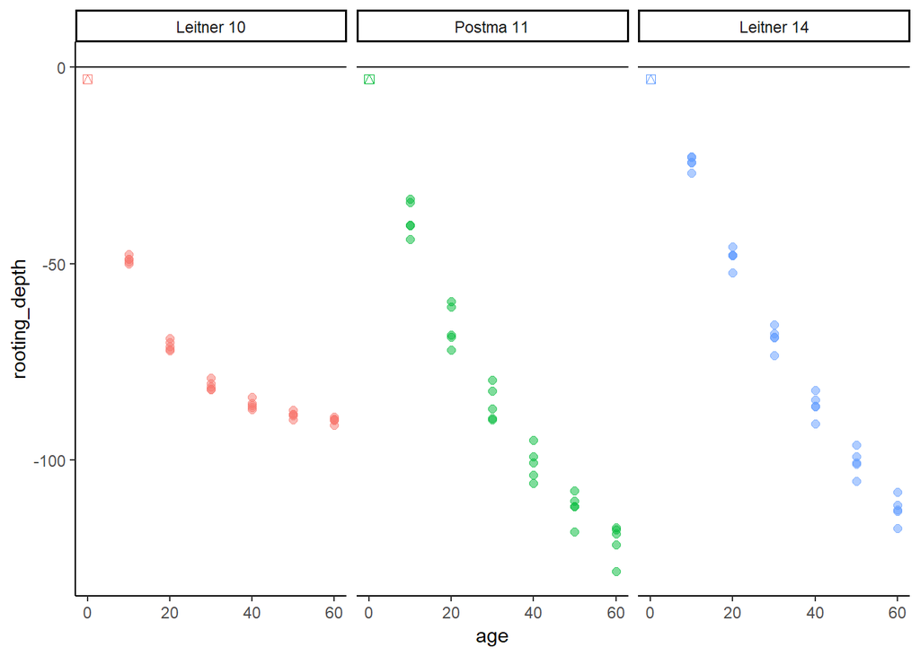

Rooting depth of the different root system examples

#### The total root length

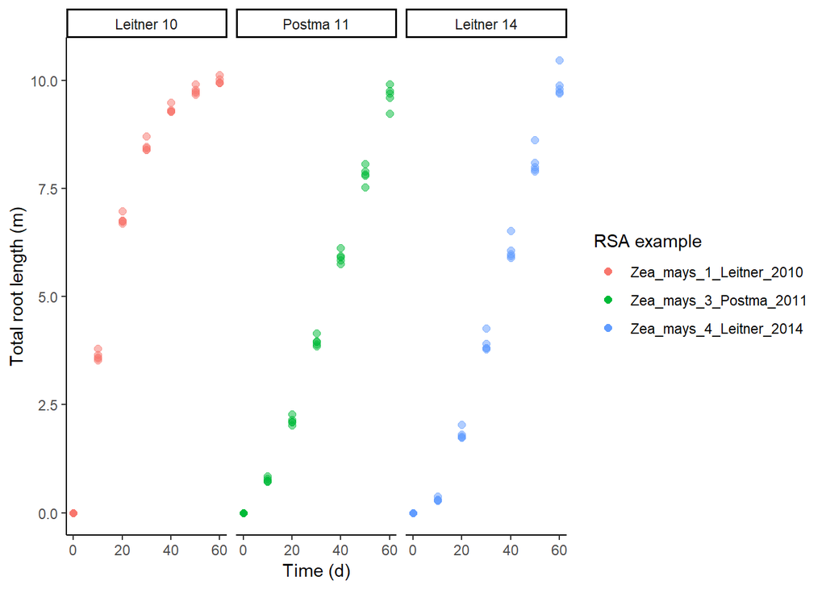

Total root length for each of the root system examples

#### Number of roots.

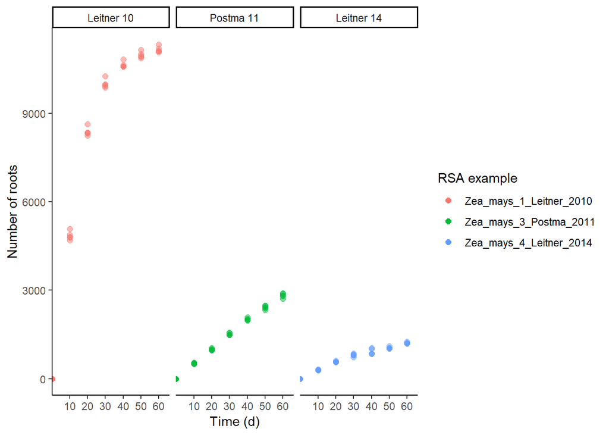

Number of different roots for each of the root system examples

Although the total root length reach a close value of ten meter for all the different rootsystems, there is a huge gap in term of number of roots between each of the root system architecture.

## The water soil potential

The pressure head of the water potential within the soil is created from the followig line of code. Here, there are three soil scenarios with three different coeficients in the drying function.

The drying function is :

$ _i = -230$

- $ _i $ = water potential in the soil at i cm below the surface.
- $ $ = drying coefficient of the soil (-300 = “humid”, -7000 = “dry” and -15.000 = “arid”).
- $ Z_i$ = the depth (cm)
- $ L $ = the maximal soil profile depth.
- $ T $ = the simulation time (day)
- -230 is the water potential in the soil at the field cappacity for a silty soil.

```r
# Creating the soil
profile_depth <- 150
z <- seq(-profile_depth, 0, by = 5)
value <- sort(rep(full_time, length(z)))
psi <- rep(-230, length(value))
z <- rep(z, ntimesteps)

soil <- NULL
for(i in c(-300, -7000, -15000)){
soil_tmp <- cbind(z, value, psi)%>%
  as.tibble()%>%
  mutate(psi = i*(((z+profile_depth)^(10))*value)/
           ((profile_depth^10)*endTime)-230,
         humid = i)
soil_tmp <- soil_tmp%>%
  mutate(id = 1:nrow(soil_tmp))
soil<- rbind(soil, soil_tmp)

}
```

## The water potential at the collar

Expressed in hecto-Pascal, the pressure head define the transpiration strenght that drags the water out of the root system. $-15.000 \ hPa$

```r
# Water potential at the collar (hPa)
tpots <- -15000
```

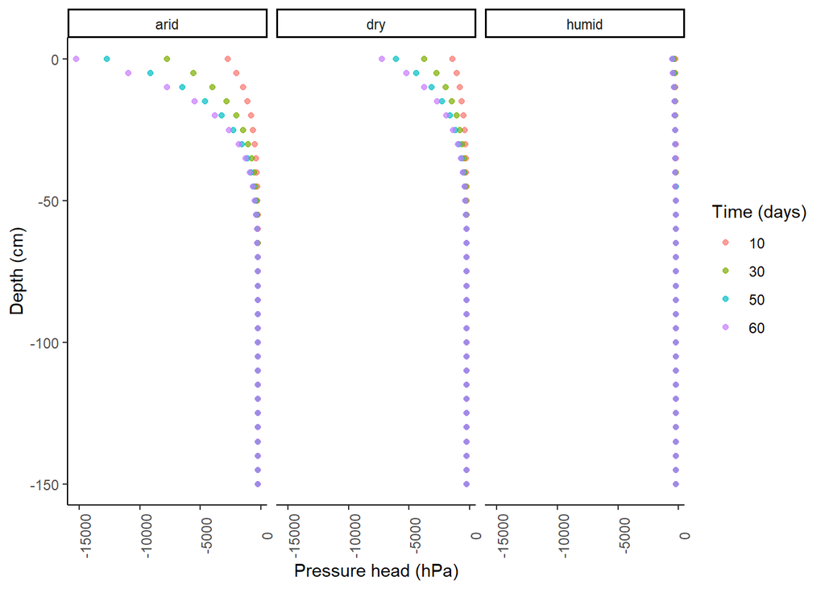

Water potential evolution during the simultaion time along the soil profile

# MARSHAL

MARSHAL provide an estimation of the conductance of the whole root system, the actual and the potential transpiration. The input needed in order to provide those relevant informations are :

```r
new_all_roots <- NULL
results<- NULL
k <- 1
# ------------------------------------------------
# Computing the root system hydraulic architecture
# ------------------------------------------------

# Total of simulation that will be initiate
all <- length(unique(all_roots$rep)) * length(unique(conductivities$scenario)) *
          length(unique(all_roots$age)) * length(unique(all_roots$ex)) *
          length(unique(soil$humid))

pb = txtProgressBar(min = 0, max = all, initial = 0, style = 3)
# Loop to run MARSHAL with the selected simulation parameters.

for(exa in unique(all_roots$ex)){# Example of RSA
  for(re in unique(all_roots$rep)){ # repetition
    for(ag in sort(as.numeric(unique(all_roots$age)))){# age of the RS
      for(sen in unique(conductivities$scenario)){ # hydraulic properties
        for(hum in unique(soil$humid)){ # Scenario of water potential in the soil

        # Progression bar
        setTxtProgressBar(pb,k)

        # Select specific Soil for the simulation
        temp_soil <- soil %>%
          filter(value == ag,
                 humid == hum)%>%
          select(-value, -humid)
        # Select specific root system for the simulation
        temp_root <- all_roots %>%
          filter(age == ag,
                 rep == re,
                 ex == exa)%>%
          as.tibble()%>%
          select(-ex)
        # Select specific conductivities
        temp_conduct <- conductivities%>%
          filter(scenario == sen)%>%
          select(-scenario)

        # -----------------------------
        # Run MARSHAL
        # -----------------------------
        hydraulics <- getSUF(temp_root,
                             temp_conduct,
                             temp_soil,
                             hetero = T,
                             Psi_collar = tpots)

        # Aggregate output from MARSHAL
        results <- rbind(results, data.frame(krs = hydraulics$krs,
                                             tact = hydraulics$tact,
                                             tpot = hydraulics$tpot,
                                             tp = tpots,
                                             scenario = sen,
                                             age = ag,
                                             rep = re,
                                             ex = exa,
                                             humid = hum,
                                             simulation = k))

        # Keep the information about the very detail hydrological parameter on
        # all the root segment only for one repetion of the plant per simulation.
        if(re >= nrep-1){
        # Format dataset to be compatible with MARSHAL output
        first <- temp_root[temp_root$node1ID == 0,]
        nodals_ids <- unique(temp_root$branchID[temp_root$type == 4 |
                                                  temp_root$type == 5])
        for(no in nodals_ids){
          temp <- temp_root%>%
           filter(branchID == no)
          temp <- temp[1,]
          connection <- data.frame(node1ID = 0,
                             node2ID = temp$node1ID,
                             branchID = temp$branchID,
                             x1 = first$x1, y1 = first$y1, z1 = first$z1,
                             x2 = temp$x1, y2 = temp$y1, z2 = temp$z1,
                             radius = temp$radius,
                             length = sqrt((first$x1-temp$x1)^2 +
                                             (first$y1-temp$y1)^2 +
                                             (first$z1-temp$z1)^2 ),
                             R = 0, G = 0, B = 0,
                             time = temp$time,
                             type = temp$type,
                             age = temp$age,
                             rep = temp$rep)
          new_table = rbind(temp_root, connection)
          temp_root = new_table
          }
        temp_root <- temp_root[order(temp_root$node2ID, decreasing = F),]

        # Merge output of MARSHAL on specific root segment
        temp_root$suf <- as.vector(hydraulics$suf)
        temp_root$suf1 <- as.vector(hydraulics$suf1)
        temp_root$kx <- as.vector(hydraulics$kx)
        temp_root$kr <- as.vector(hydraulics$kr)
        temp_root$jr <- as.vector(hydraulics$jr)
        temp_root$psi <- as.vector(hydraulics$psi)
        temp_root$jxl <- as.vector(hydraulics$jxl)
        temp_root$psi_soil <- as.vector(hydraulics$psi_soil)
        # Add the simulation specificity to the dataset
        temp_root$scenario <- sen
        temp_root$ex <- exa
        temp_root$humid <- hum
        temp_root$rep <- re
        new_all_roots <- rbind(new_all_roots, temp_root)
        }
        k <- k + 1
        }
      }
    }
  }
}
# Save the results
# write_csv(new_all_roots, "new_all_roots.csv")
# new_all_roots <- read.csv("new_all_roots.csv")
```

## Results :

Once the simulation are computed, it is possible to visualize the output on a various form

### Standard uptake fraction

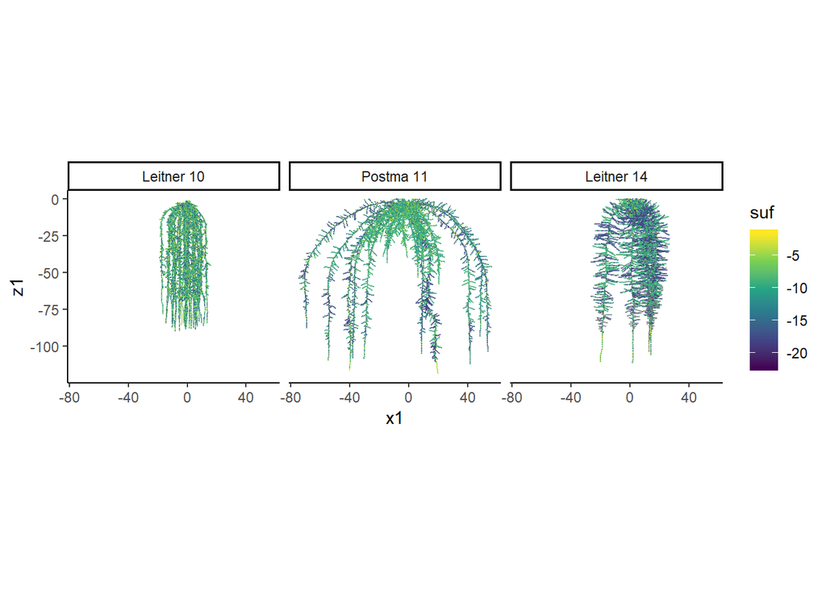

The absorption

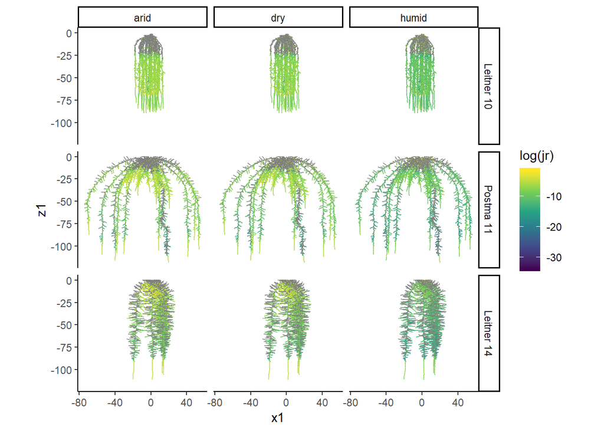

The axial fluxes

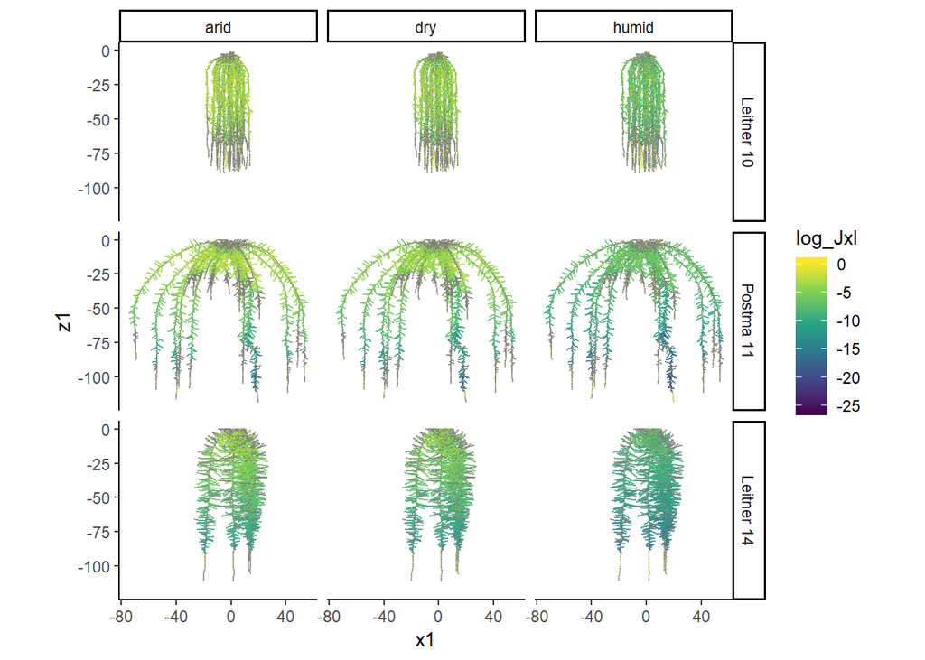

The smallest region on which more or less 50% of the water uptake occurs

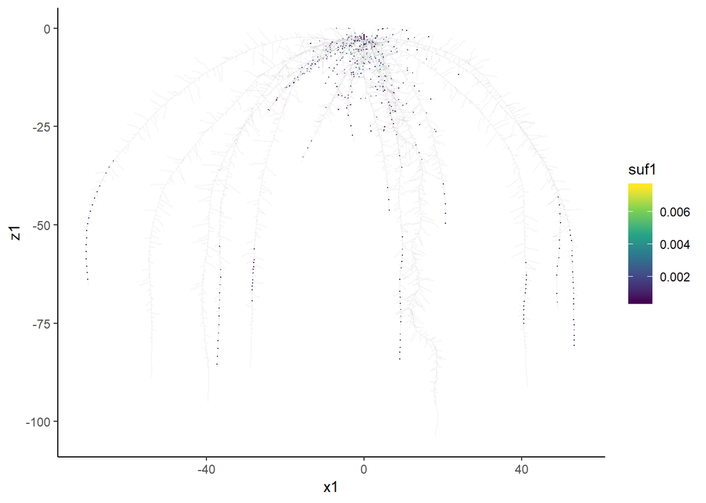

| ex | high |
| --- | --- |
| Zea_mays_3_Postma_2011 | 0.5401256 |

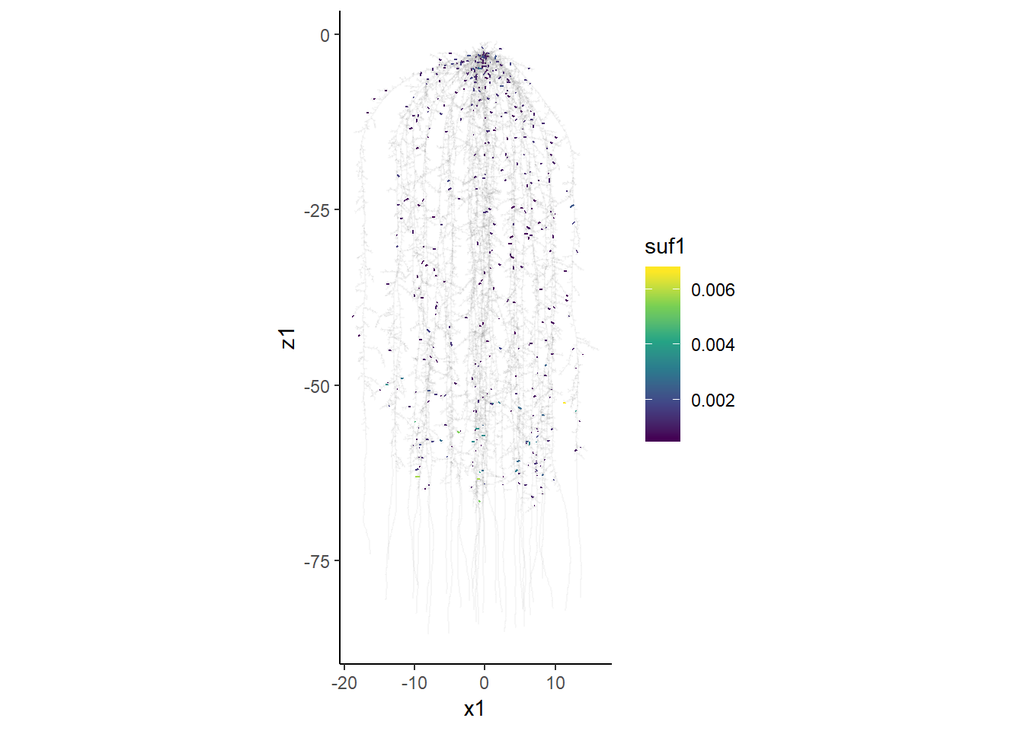

| ex | high |
| --- | --- |
| Zea_mays_1_Leitner_2010 | 0.5066278 |

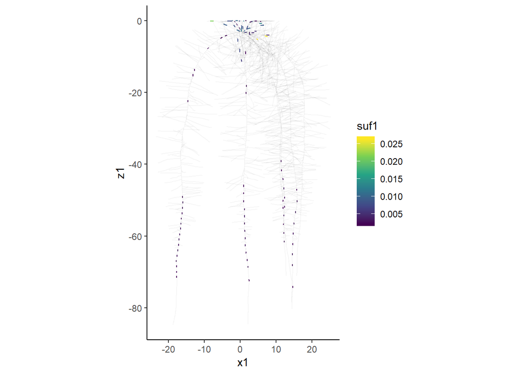

| ex | high |
| --- | --- |
| Zea_mays_4_Leitner_2014 | 0.4829675 |

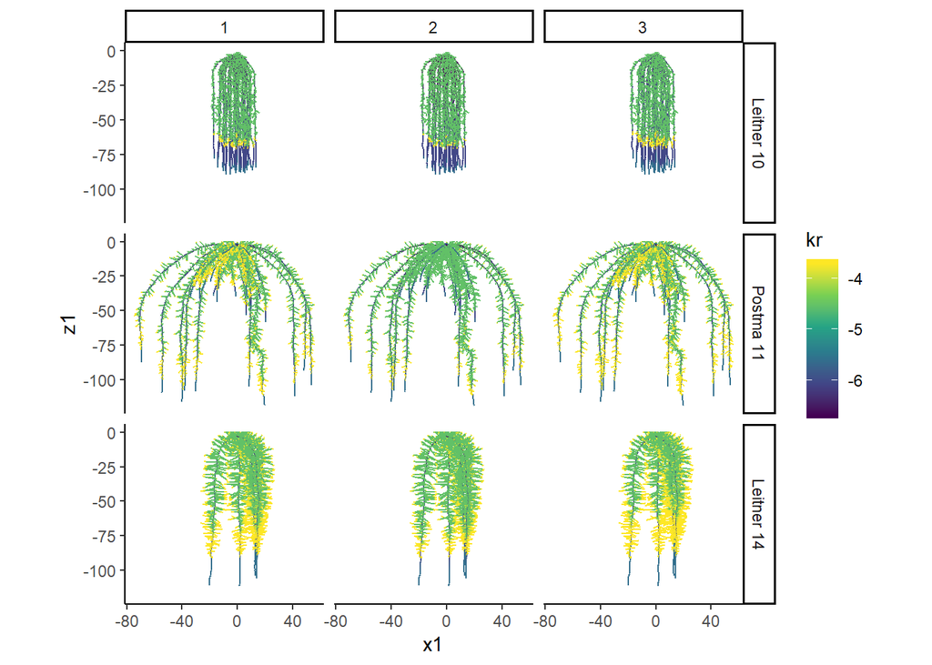

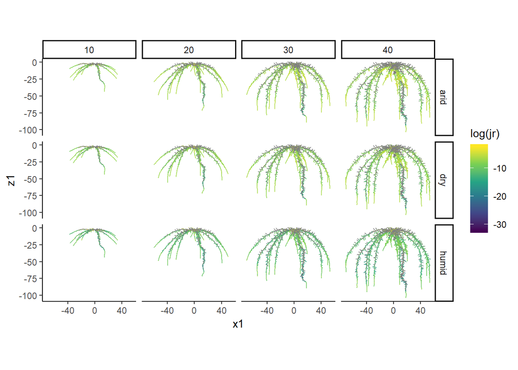

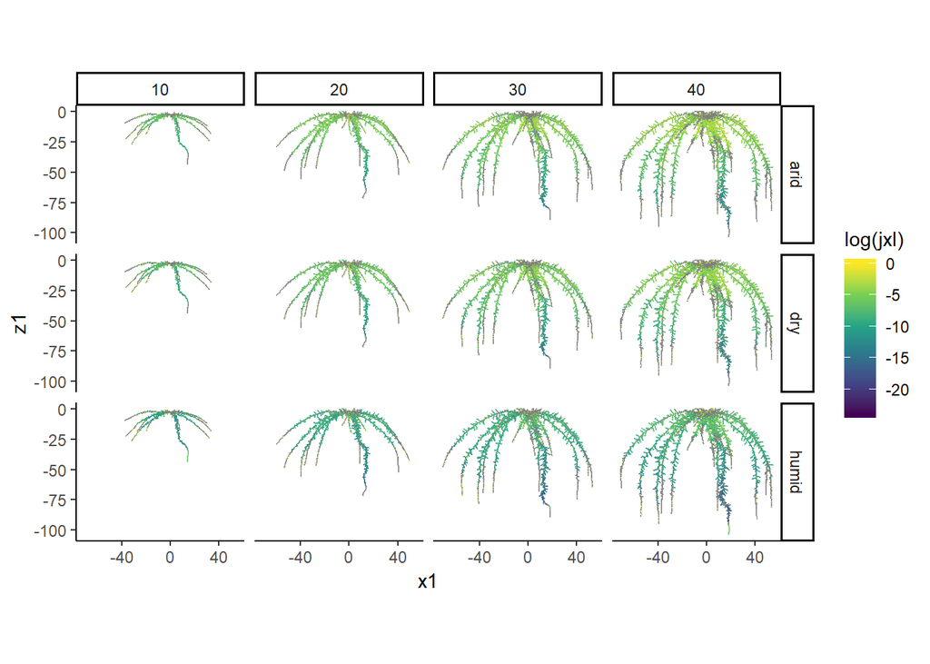

To look at the different hydraulic marco-properties along the profile depth, we took the mean values of the variable total on every two centimeters.

```r
# For the two repetions on which we have values on each segment,
# we take the mean values of the sum of each variables.
dens <- new_all_roots%>%
  mutate(age = as.numeric(age))%>%
  group_by(type, age, rz1 = round(z1/2)*2, # on every two cm of the profile
           scenario, ex, humid)%>%
  summarise(root = sum(length)/2, # The mean of the sum on the two repetitions
            su = sum(suf)/2,
            su1 = sum(suf1)/2,
            j = sum(jr)/2,
            jx = sum(jxl)/2,
            p = sum(psi)/2,
            kr = sum(kr)/2)
```

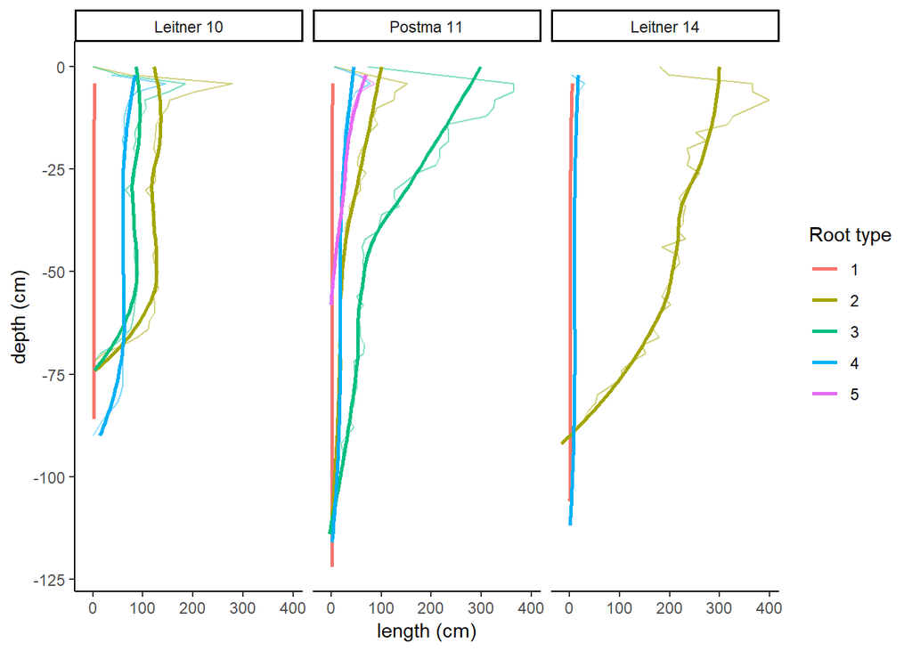

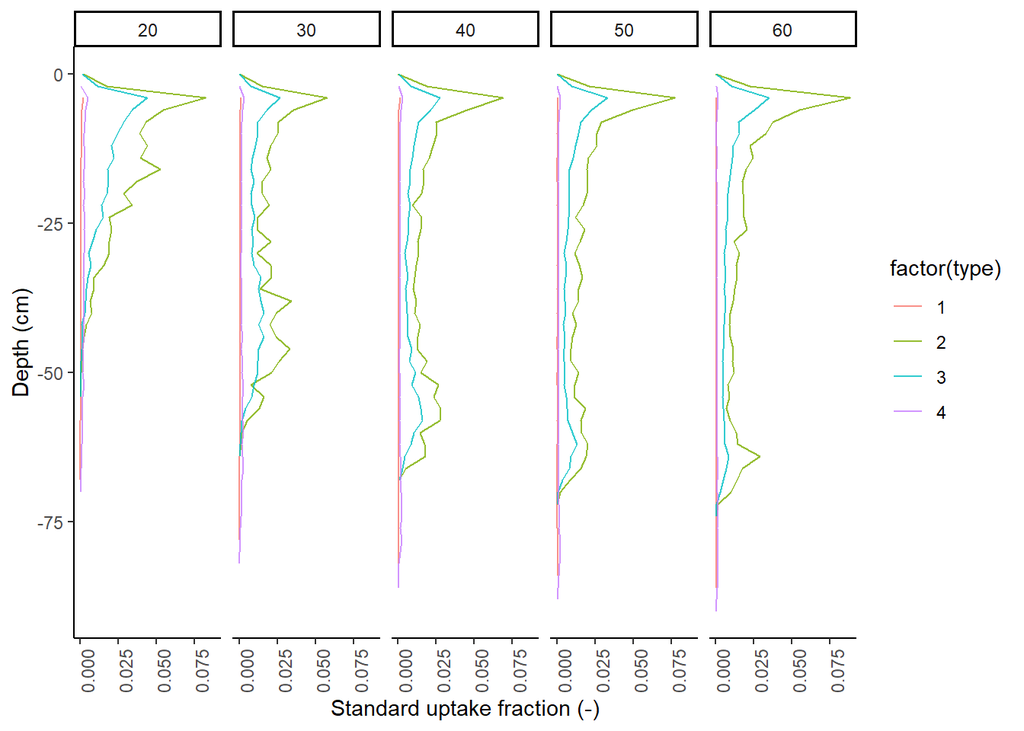

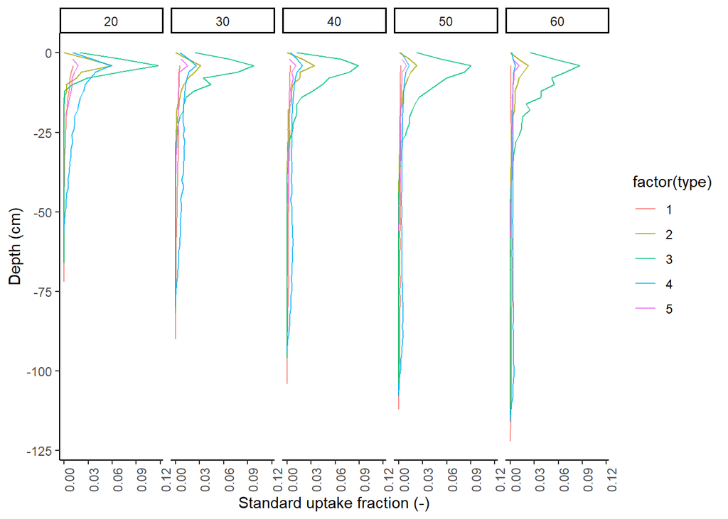

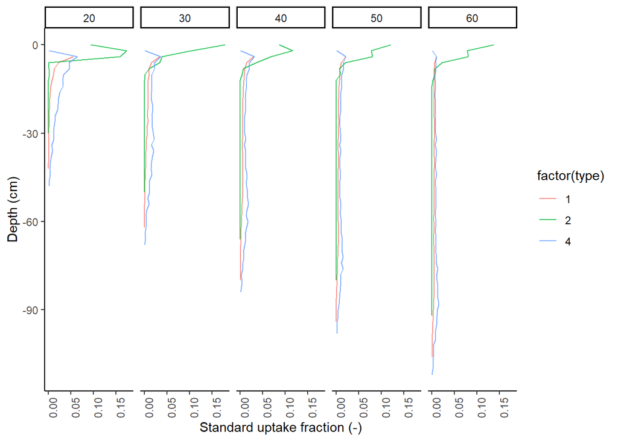

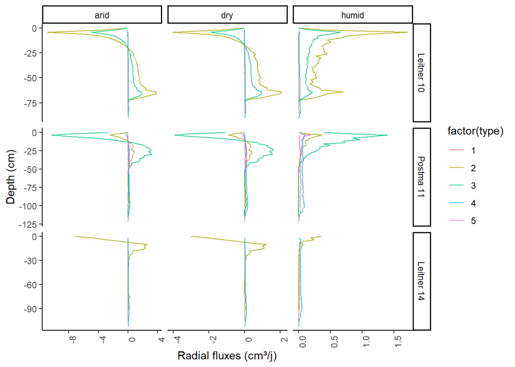

Comparison of the radial fluxes between the different soil scenarios and the root system architectures

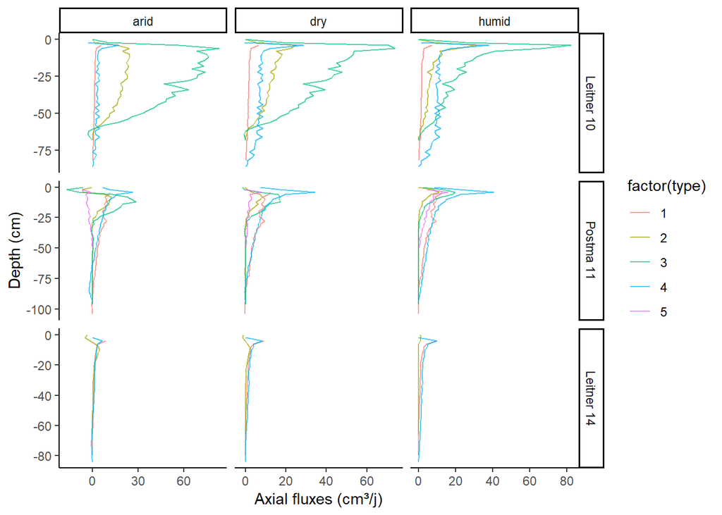

Comparison of the axial fluxes between the different soil scenarios and the root system architectures

```r
dens%>%
  filter(age == 40,
         scenario == 1)%>%
  ggplot(aes(rz1, jx, colour=factor(type))) +
  geom_line(alpha = 0.7) +
  #geom_smooth(se=F) +
  coord_flip() +
  theme_classic()+
  xlab("Depth (cm)") +
  ylab("Axial fluxes (cm³/j)")+
  facet_grid(ex~humid, scales = "free", labeller = as_labeller(babbel))
```

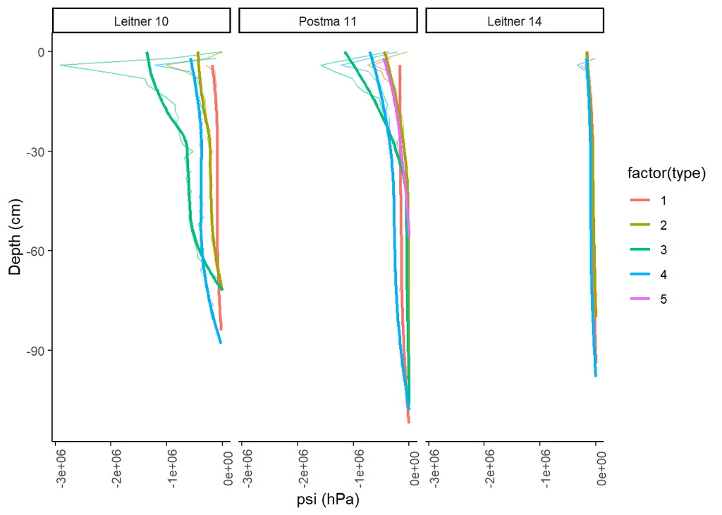

[figure not shown]

```r
dens%>%
  filter(age == 50,
         humid == unique(dens$humid)[3],
         scenario == 2)%>%
  ggplot(aes(rz1, p, colour=factor(type))) +
  geom_line(alpha = 0.5) +
  geom_smooth(se=F) +
  coord_flip() +
  theme_classic()+
  xlab("Depth (cm)") +
  ylab("psi (hPa)")+
  theme(axis.text.x=element_text(angle=90)) +
  facet_wrap(~ex, labeller = as_labeller(babbel))
```

```r
Transpiration<- results%>%
  mutate(humid = as.character(humid))%>%
  group_by(age, rep, scenario, humid, ex)%>%
  summarise(Tpot = max(tpot, tact),
            Tact = min(tpot, tact))
```

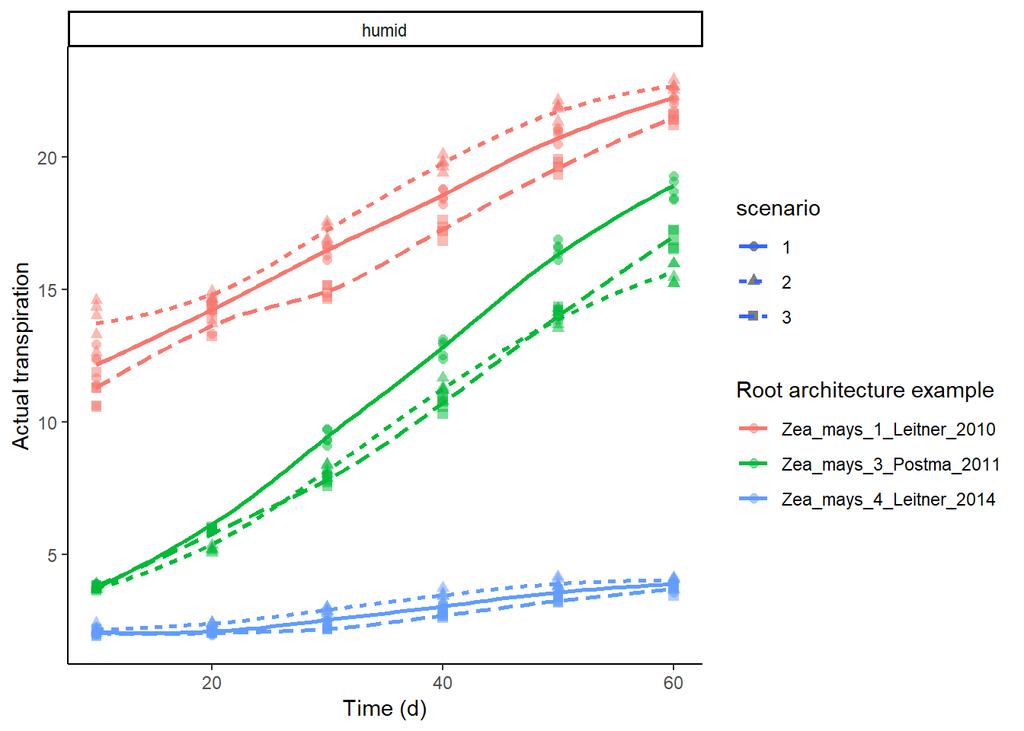

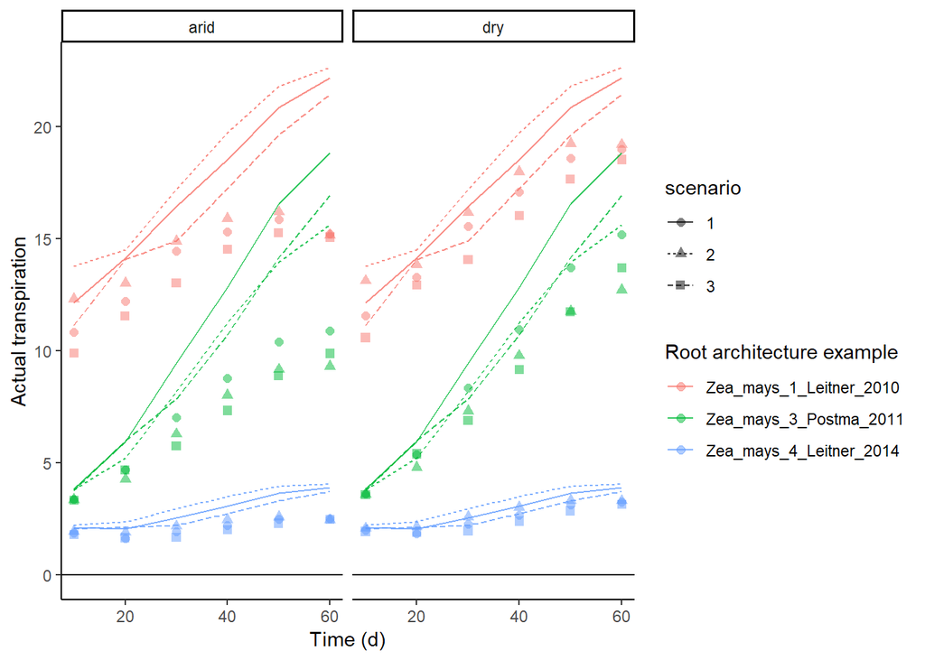

The different line represent a potential transpiration.